# Estadística Avanzada: A3 - Modelización predictiva

Autor: Raúl Vicente Ferrer

Diciembre 2021

```r
# https://cran.r-project.org/web/packages/ggplot2/index.html
if (!require('ggplot2')) install.packages('ggplot2'); library('ggplot2')
# https://cran.r-project.org/web/packages/dplyr/index.html
if (!require('dplyr')) install.packages('dplyr'); library('dplyr')
# https://cran.r-project.org/web/packages/dplyr/index.html
if (!require('knitr')) install.packages('knitr'); library('knitr')
# https://cran.r-project.org/web/packages/corrplot/index.html
if (!require('corrplot')) install.packages('corrplot'); library('corrplot')
# https://cran.r-project.org/web/packages/faraway/index.html
if (!require('faraway')) install.packages('faraway'); library('faraway')
# https://cran.r-project.org/web/packages/ResourceSelection/index.html
if (!require('ResourceSelection')) install.packages('ResourceSelection'); library('ResourceSelection')
# https://cran.r-project.org/web/packages/pROC/index.html
if (!require('pROC')) install.packages('pROC'); library('pROC')
```

# 1 Regresión lineal

Carga del dataset:

```r
df <- read.csv("./dat_Air.csv", header=TRUE)
```

```r
summary(df)
```

```
##     Estacion     latitud         longitud         Fecha
##  Min.   :12   Min.   :43.52   Min.   :-5.691   Length:7464
##  1st Qu.:12   1st Qu.:43.52   1st Qu.:-5.691   Class :character
##  Median :12   Median :43.52   Median :-5.691   Mode  :character
##  Mean   :12   Mean   :43.52   Mean   :-5.691
##  3rd Qu.:12   3rd Qu.:43.52   3rd Qu.:-5.691
##  Max.   :12   Max.   :43.52   Max.   :-5.691
##
##     Periodo           SO2               H2S               NO
##  Min.   : 1.00   Min.   :  1.000   Min.   : 0.800   Min.   :  1.00
##  1st Qu.: 6.75   1st Qu.:  2.000   1st Qu.: 1.000   1st Qu.:  1.00
##  Median :12.50   Median :  3.000   Median : 2.000   Median :  1.00
##  Mean   :12.50   Mean   :  4.804   Mean   : 2.526   Mean   :  4.14
##  3rd Qu.:18.25   3rd Qu.:  6.000   3rd Qu.: 3.400   3rd Qu.:  3.00
##  Max.   :24.00   Max.   :105.000   Max.   :33.000   Max.   :111.00
##                  NA's   :54        NA's   :50       NA's   :63
##       NO2             NOX               O3            PM10
##  Min.   : 2.00   Min.   :  2.00   Min.   : 1.0   Min.   :  0.00
##  1st Qu.: 5.00   1st Qu.:  5.00   1st Qu.:20.0   1st Qu.: 15.00
##  Median :10.00   Median : 11.00   Median :47.0   Median : 24.00
##  Mean   :12.96   Mean   : 18.29   Mean   :42.2   Mean   : 42.83
##  3rd Qu.:18.00   3rd Qu.: 23.00   3rd Qu.:61.0   3rd Qu.: 45.00
##  Max.   :68.00   Max.   :221.00   Max.   :98.0   Max.   :724.00
##  NA's   :63      NA's   :52       NA's   :62     NA's   :43
##       PM25            BEN               TOL               MXIL
##  Min.   : 0.00   Min.   : 0.1000   Min.   :  0.100   Min.   : 0.100
##  1st Qu.: 7.00   1st Qu.: 0.1000   1st Qu.:  0.200   1st Qu.: 0.400
##  Median :11.00   Median : 0.2000   Median :  0.500   Median : 0.900
##  Mean   :12.88   Mean   : 0.6108   Mean   :  1.883   Mean   : 1.935
##  3rd Qu.:16.00   3rd Qu.: 0.5000   3rd Qu.:  1.400   3rd Qu.: 2.000
##  Max.   :96.00   Max.   :21.8000   Max.   :160.300   Max.   :53.600
##  NA's   :142     NA's   :88        NA's   :86        NA's   :86
##     Dir_Aire          Vel             Tmp              HR
##  Min.   :  1.0   Min.   :0.730   Min.   : 1.10   Min.   : 30.00
##  1st Qu.: 73.0   1st Qu.:1.000   1st Qu.:11.70   1st Qu.: 81.00
##  Median :215.0   Median :1.650   Median :15.20   Median : 92.00
##  Mean   :181.8   Mean   :2.409   Mean   :14.69   Mean   : 88.03
##  3rd Qu.:268.0   3rd Qu.:3.530   3rd Qu.:18.20   3rd Qu.: 99.00
##  Max.   :360.0   Max.   :9.760   Max.   :26.40   Max.   :100.00
##
##       PRB             RS              LL
##  Min.   : 991   Min.   : 24.0   Min.   : 0.00000
##  1st Qu.:1012   1st Qu.: 37.0   1st Qu.: 0.00000
##  Median :1016   Median : 46.0   Median : 0.00000
##  Mean   :1016   Mean   :133.5   Mean   : 0.08355
##  3rd Qu.:1020   3rd Qu.:184.0   3rd Qu.: 0.00000
##  Max.   :1031   Max.   :689.0   Max.   :13.00000
##
```

```r
str(df)
```

```
## 'data.frame':    7464 obs. of  23 variables:
##  $ Estacion: int  12 12 12 12 12 12 12 12 12 12 ...
##  $ latitud : num  43.5 43.5 43.5 43.5 43.5 ...
##  $ longitud: num  -5.69 -5.69 -5.69 -5.69 -5.69 ...
##  $ Fecha   : chr  "11/7/2021" "11/7/2021" "11/7/2021" "11/7/2021" ...
##  $ Periodo : int  24 23 22 21 20 19 18 17 16 15 ...
##  $ SO2     : int  1 1 1 1 1 1 1 1 1 1 ...
##  $ H2S     : num  18.3 6.2 4.3 2.7 2.1 ...
##  $ NO      : int  5 2 1 4 2 1 1 1 1 2 ...
##  $ NO2     : int  36 22 19 21 18 10 8 8 10 13 ...
##  $ NOX     : int  43 24 20 26 20 10 7 9 10 16 ...
##  $ O3      : int  5 10 14 11 16 24 36 55 53 52 ...
##  $ PM10    : int  95 80 38 36 30 21 15 24 14 15 ...
##  $ PM25    : int  30 23 15 12 12 17 12 10 6 10 ...
##  $ BEN     : num  1.6 0.7 0.6 0.9 0.2 ...
##  $ TOL     : num  2.3 1.8 1.1 1.3 0.6 ...
##  $ MXIL    : num  3.2 2.7 3.1 2.2 0.8 ...
##  $ Dir_Aire: int  260 201 296 185 297 295 309 23 241 24 ...
##  $ Vel     : num  1.49 0.98 0.98 0.99 0.99 ...
##  $ Tmp     : num  11.8 11.6 11.2 11.9 12.4 ...
##  $ HR      : int  93 93 92 88 85 83 76 71 67 61 ...
##  $ PRB     : int  1025 1025 1025 1026 1026 1026 1026 1026 1026 1026 ...
##  $ RS      : int  36 36 37 37 37 37 37 47 116 194 ...
##  $ LL      : num  0 0 0 0 0 0 0 0 0 0 ...
```

## 1.1 Estudio de correlación lineal

- Matriz de correlación:

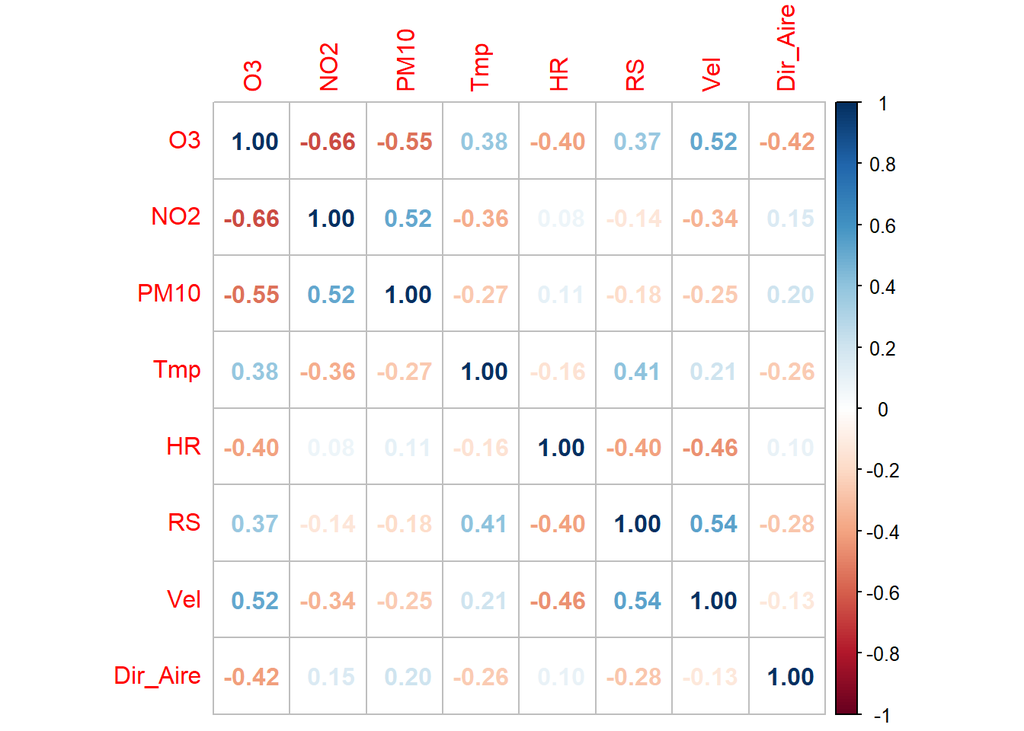

```r
# calculamos y representamos la matriz de correlación
datos_corr <- df[, c(11, 9, 12, 19, 20, 22, 18, 17)]
M <- cor(datos_corr, method = "pearson", use = "pairwise.complete.obs")
corrplot(M, method = "number")
```

- ¿Cual de los contaminantes atmosféricos citados anteriormente, tienen una mayor relación lineal con la RS? Interpretar las relaciones de dicho contaminante con la RS y también con el resto de variables meteorológicas. El contaminante atmosférico que tiene una mayor relación lineal con RS es O3 ya que, como se puede observar en la matriz de correlación, su coeficiente es el mayor (en valor absoluto). La relación que tienen es en sentido directo y de magnitud débil. Tmp: relación en sentido directo y de magnitud débil. HR: relación en sentido inverso y de magnitud débil. Vel: relación en sentido directo y de magnitud moderada. Dir_Aire: relación en sentido inverso y de magnitud débil.
- Se toma la media diaria de cada una de las variables del apartado a) y posteriormente se estudia de nuevo la relación pedida en dicho apartado. ¿Existe alguna diferencia en la relación entre las nuevas variables construidas con los valores medios diarios, con respecto a los resultados obtenidos anteriormente?

Matriz de correlación de las nuevas variables:

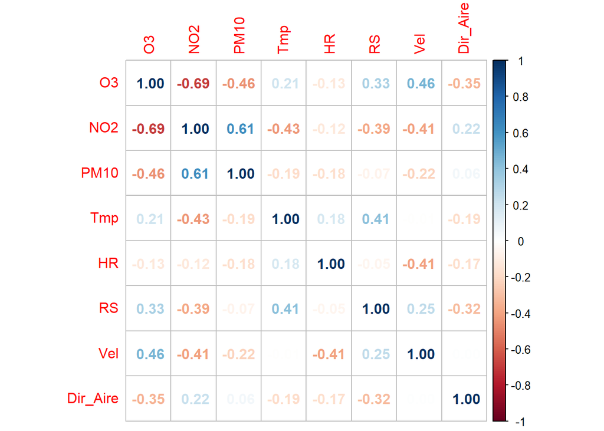

```r
# Media diaría de cada variable
byday = aggregate(df[,c("O3", "NO2", "PM10", "Tmp", "HR", "RS", "Vel", "Dir_Aire")], by = list(df$Fecha), mean)
# calculamos y representamos la matriz de correlación
datos_corr <- byday[, c(2:9)]
M_byday <- cor(datos_corr, method = "pearson", use = "pairwise.complete.obs")
corrplot(M_byday, method = "number")
```

Diferencias entre las dos matrices:

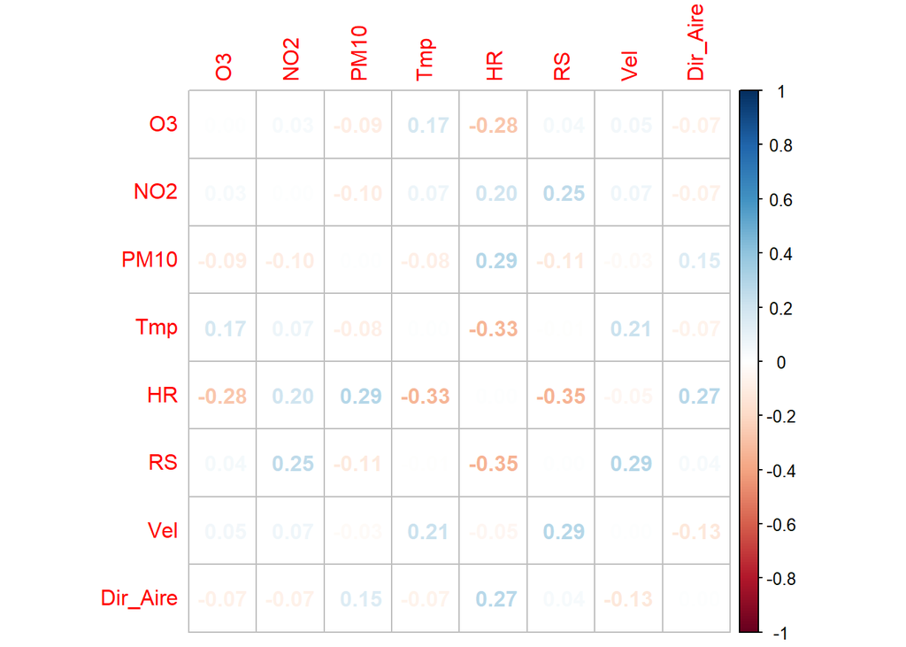

```r
M_dif <- M-M_byday
corrplot(M_dif, method = "number")
```

Se pueden observar algunas diferencias significativas.

## 1.2 Modelo de regresión lineal

- Estimar por mínimos cuadrados ordinarios un modelo lineal que explique la variable O3 en función de la radiación solar (RS). Se evaluará la bondad del ajuste, a partir del coeficiente de determinación.

```r
Model.1.2.a <- lm(O3~RS, data=df)
summary(Model.1.2.a)
```

```
##
## Call:
## lm(formula = O3 ~ RS, data = df)
##
## Residuals:
##     Min      1Q  Median      3Q     Max
## -44.494 -19.494   2.075  17.329  60.383
##
## Coefficients:
##              Estimate Std. Error t value Pr(>|t|)
## (Intercept) 34.365621   0.343164  100.14   <2e-16 ***
## RS           0.059115   0.001721   34.34   <2e-16 ***
## ---
## Signif. codes:  0 '***' 0.001 '**' 0.01 '*' 0.05 '.' 0.1 ' ' 1
##
## Residual standard error: 22.06 on 7400 degrees of freedom
##   (62 observations deleted due to missingness)
## Multiple R-squared:  0.1375, Adjusted R-squared:  0.1374
## F-statistic:  1179 on 1 and 7400 DF,  p-value: < 2.2e-16
```

El coeficiente de determinación es 0.1374, por lo tanto, la calidad del ajuste es mala. Como era de esperar, ya que la correlación entre ambas variables es débil.

- Modelo de regresión lineal, tomando como variable dependiente (O3) y la variable explicativa PM10_cat

Creación de la variable PM10_cat:

```r
PM10_cat <- cut(df$PM10, breaks = c(0, 40, 60, 120, 160, 724),
                labels = c("Muy buena", "Buena", "Mejorable", "Mala", "Muy mala"))
df_1.2 <- data.frame(df, PM10_cat)
```

Modelo de regresión lineal

```r
Model.1.2.b<- lm(O3~PM10_cat, data=df)
summary(Model.1.2.b)
```

```
##
## Call:
## lm(formula = O3 ~ PM10_cat, data = df)
##
## Residuals:
##     Min      1Q  Median      3Q     Max
## -50.576 -10.576   0.424  11.424  66.107
##
## Coefficients:
##                   Estimate Std. Error t value Pr(>|t|)
## (Intercept)        51.5765     0.2419  213.24   <2e-16 ***
## PM10_catBuena     -22.3445     0.7197  -31.05   <2e-16 ***
## PM10_catMejorable -36.6810     0.6592  -55.65   <2e-16 ***
## PM10_catMala      -44.0641     1.1624  -37.91   <2e-16 ***
## PM10_catMuy mala  -44.6837     1.0682  -41.83   <2e-16 ***
## ---
## Signif. codes:  0 '***' 0.001 '**' 0.01 '*' 0.05 '.' 0.1 ' ' 1
##
## Residual standard error: 17.69 on 7387 degrees of freedom
##   (72 observations deleted due to missingness)
## Multiple R-squared:  0.4455, Adjusted R-squared:  0.4452
## F-statistic:  1483 on 4 and 7387 DF,  p-value: < 2.2e-16
```

El coeficiente de determinación es 0.4452, por lo tanto, la calidad del ajuste es baja, a pesar de que la relación entre las variables es moderada.

## 1.3 Modelo de regresión lineal múltiple

Explicar el nivel de ozono en función de la radiación solar (RS),concentración de dióxido de nitrógeno (NO2), temperatura (Tmp) y dirección del aire (Dir_Aire).

- Primero, se añadirá al modelo del apartado a), la variable explicativa (Dir_Aire).¿El modelo ha mejorado?

```r
Model.1.3.a <- lm(O3~RS+Dir_Aire, data=df)
summary(Model.1.3.a)
```

```
##
## Call:
## lm(formula = O3 ~ RS + Dir_Aire, data = df)
##
## Residuals:
##    Min     1Q Median     3Q    Max
## -51.69 -17.21   1.00  15.53  58.02
##
## Coefficients:
##              Estimate Std. Error t value Pr(>|t|)
## (Intercept) 51.053991   0.604391   84.47   <2e-16 ***
## RS           0.043900   0.001676   26.19   <2e-16 ***
## Dir_Aire    -0.080691   0.002476  -32.59   <2e-16 ***
## ---
## Signif. codes:  0 '***' 0.001 '**' 0.01 '*' 0.05 '.' 0.1 ' ' 1
##
## Residual standard error: 20.63 on 7399 degrees of freedom
##   (62 observations deleted due to missingness)
## Multiple R-squared:  0.2457, Adjusted R-squared:  0.2455
## F-statistic:  1205 on 2 and 7399 DF,  p-value: < 2.2e-16
```

El coeficiente de determinación es 0.2455, por lo tanto, la calidad del ajuste ha aumentado, pero sigue siendo mala.

- Posteriormente se añade al modelo anterior la variable (NO2). ¿Existe una mejora del modelo?

```r
Model.1.3.b <- lm(O3~RS+Dir_Aire+NO2, data=df)
summary(Model.1.3.b)
```

```
##
## Call:
## lm(formula = O3 ~ RS + Dir_Aire + NO2, data = df)
##
## Residuals:
##     Min      1Q  Median      3Q     Max
## -51.531 -11.358   0.036  10.821  56.552
##
## Coefficients:
##              Estimate Std. Error t value Pr(>|t|)
## (Intercept) 67.863089   0.501096  135.43   <2e-16 ***
## RS           0.034141   0.001257   27.16   <2e-16 ***
## Dir_Aire    -0.063742   0.001860  -34.27   <2e-16 ***
## NO2         -1.435140   0.018681  -76.82   <2e-16 ***
## ---
## Signif. codes:  0 '***' 0.001 '**' 0.01 '*' 0.05 '.' 0.1 ' ' 1
##
## Residual standard error: 15.39 on 7396 degrees of freedom
##   (64 observations deleted due to missingness)
## Multiple R-squared:  0.5805, Adjusted R-squared:  0.5804
## F-statistic:  3412 on 3 and 7396 DF,  p-value: < 2.2e-16
```

El coeficiente de determinación es 0.5804, por lo tanto, la calidad del ajuste ha aumentado y es moderada.

- Se toma la variable (Tmp) y se añade al modelo anterior. Se pide comprobar la presencia o no de colinealidad entre las variables (RS) y (Tmp). Según la conclusión obtenida, discutir si sería indicado o no añadir la variable (Tmp) al modelo. De ser afirmativa la respuesta, construye el modelo e interpreta el resultado.

```r
# Coeficiente de correlación entre las variables
cor(x = df$RS, y = df$Tmp, method = "pearson")
```

```
## [1] 0.4060147
```

```r
# comparación de las estimaciones de modelos
Model.1.3.c <- lm(O3~RS+Dir_Aire+NO2+Tmp, data=df)
model.RS <- lm(O3~RS, data=df)
model.Tmp<- lm(O3~Tmp, data=df)
summary(Model.1.3.c)
```

```
##
## Call:
## lm(formula = O3 ~ RS + Dir_Aire + NO2 + Tmp, data = df)
##
## Residuals:
##    Min     1Q Median     3Q    Max
## -51.49 -11.32   0.13  10.84  56.06
##
## Coefficients:
##              Estimate Std. Error t value Pr(>|t|)
## (Intercept) 66.444001   0.909846  73.028   <2e-16 ***
## RS           0.033278   0.001339  24.858   <2e-16 ***
## Dir_Aire    -0.063273   0.001877 -33.712   <2e-16 ***
## NO2         -1.423202   0.019740 -72.097   <2e-16 ***
## Tmp          0.088130   0.047166   1.869   0.0617 .
## ---
## Signif. codes:  0 '***' 0.001 '**' 0.01 '*' 0.05 '.' 0.1 ' ' 1
##
## Residual standard error: 15.38 on 7395 degrees of freedom
##   (64 observations deleted due to missingness)
## Multiple R-squared:  0.5807, Adjusted R-squared:  0.5805
## F-statistic:  2561 on 4 and 7395 DF,  p-value: < 2.2e-16
```

```r
summary(model.RS)
```

```
##
## Call:
## lm(formula = O3 ~ RS, data = df)
##
## Residuals:
##     Min      1Q  Median      3Q     Max
## -44.494 -19.494   2.075  17.329  60.383
##
## Coefficients:
##              Estimate Std. Error t value Pr(>|t|)
## (Intercept) 34.365621   0.343164  100.14   <2e-16 ***
## RS           0.059115   0.001721   34.34   <2e-16 ***
## ---
## Signif. codes:  0 '***' 0.001 '**' 0.01 '*' 0.05 '.' 0.1 ' ' 1
##
## Residual standard error: 22.06 on 7400 degrees of freedom
##   (62 observations deleted due to missingness)
## Multiple R-squared:  0.1375, Adjusted R-squared:  0.1374
## F-statistic:  1179 on 1 and 7400 DF,  p-value: < 2.2e-16
```

```r
summary(model.Tmp)
```

```
##
## Call:
## lm(formula = O3 ~ Tmp, data = df)
##
## Residuals:
##     Min      1Q  Median      3Q     Max
## -53.664 -17.853   1.738  17.125  54.733
##
## Coefficients:
##             Estimate Std. Error t value Pr(>|t|)
## (Intercept) 12.35945    0.88193   14.01   <2e-16 ***
## Tmp          2.03308    0.05752   35.35   <2e-16 ***
## ---
## Signif. codes:  0 '***' 0.001 '**' 0.01 '*' 0.05 '.' 0.1 ' ' 1
##
## Residual standard error: 21.97 on 7400 degrees of freedom
##   (62 observations deleted due to missingness)
## Multiple R-squared:  0.1445, Adjusted R-squared:  0.1443
## F-statistic:  1249 on 1 and 7400 DF,  p-value: < 2.2e-16
```

```r
# Cáculo de FIV
vif(Model.1.3.c)
```

```
##       RS Dir_Aire      NO2      Tmp
## 1.243470 1.119873 1.154998 1.371241
```

```r
# Se compara con 1/(1-R2)
1/(1-summary(Model.1.3.c)$r.squared)
```

```
## [1] 2.385102
```

## 1.4 Diagnosis del modelo

- Para la diagnosis se escoge el modelo construído en el apartado b) y se piden dos gráficos: uno con los valores ajustados frente a los residuos (que nos permitirá ver si la varianza es constante) y el gráfico cuantil-cuantil que compara los residuos del modelo con los valores de una variable que se distribuye normalmente(QQ plot). Interpretar los resultados.

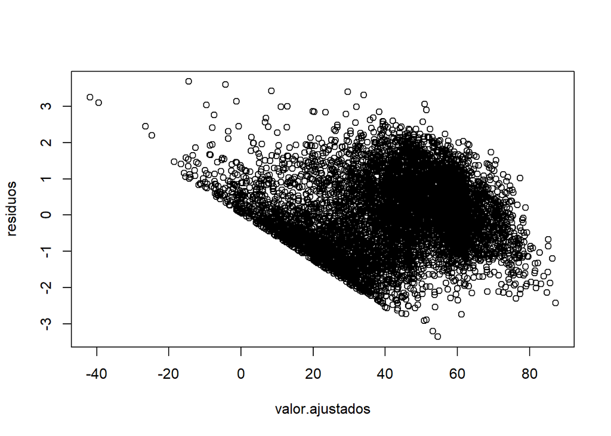

```r
residuos <- rstandard(Model.1.3.b)
valor.ajustados <- fitted(Model.1.3.b)
plot(valor.ajustados, residuos)
```

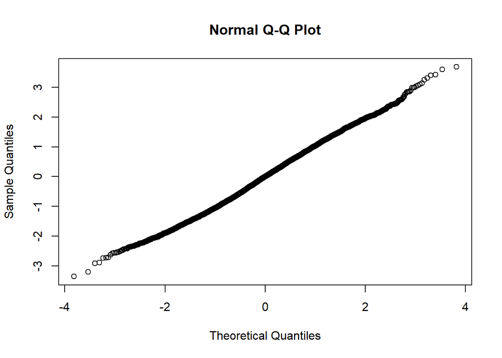

```r
qqnorm(residuos)
```

A la vista del gráfico se observa un patrón de dispersión irregular. Es decir no es un patrón aleatorio de los residuos alrededor de cero, muestra cierto tipo de estructura. Esto indica que no se cumple el supuesto de varianza constante en los errores del modelo. Por otro lado el Q_Q plot, muestra que los datos se ajustan bien a una normal.

## 1.5 Predicción del modelo

- Según el modelo del apartado c), calcular la concentración de O3, si se tienen valores de RS de 180, NO2 de 15, Dir_Aire de 250 grados y Tmp de 20 grados centígrados.

```r
newdata = data.frame(RS=180, NO2=15, Dir_Aire=250, Tmp=20)
predict(Model.1.3.c, newdata)
```

```
##        1
## 37.03044
```

Se obtiene un valor de 37.03044 𝜇𝑔/𝑚3.

# 2 Regresión logística

Estudio de la concentración de O3 del aire de una determinada ciudad.

Primera codificación de la variable icO3:

```r
icO3 <- cut(df$O3, breaks = c(0, 80, 100),
                labels = c("buena", "mejorable"))
df_2a <- data.frame(df, icO3)
```

Segunda codificación de la variable icO3:

```r
df_2b <- df_2a
df_2b$icO3 <- as.numeric(df_2b$icO3)
df_2b$icO3[df_2b$icO3 == "1"] = 0
df_2b$icO3[df_2b$icO3 == "2"] = 1
df_2b$icO3[is.na(df_2b$icO3)] = 1
df_2b$icO3 <- as.factor(df_2b$icO3)
summary(df_2b$icO3)
```

```
##    0    1
## 7238  226
```

## 2.1 Estudio de relaciones entre variables. Análisis crudo de posibles factores de riesgo

- Se visualiza la relación entre icO3 y las variables independientes: RS, Vel y HR. Para ello se recodificaran las variables RS y Vel, dejando la variable cuantitativa HR, tal como está en la base de datos. Para comprobar si existe asociación entre las variable dependiente y cada una de las variables explicativas, se aplicará el test Chi-cuadrado de Pearson. Un resultado significativo nos dirá que existe asociación.

Codificación de las variables RS_cat2 y Vel_cat2:

```r
RS_cat2 <- cut(df_2b$RS, breaks = c(0, 100, 700),
                labels = c("normal_baja", "normal_alta"))
Vel_cat2 <- cut(df_2b$Vel, breaks = c(0, 3, 10),
                labels = c("flojo", "moderado"))
df_2b <- data.frame(df_2b, RS_cat2, Vel_cat2)
```

Visualización y test Chi-cuadrado de Pearson de la relación icO3 - RS_cat2:

```r
tr<-table(df_2b$icO3,df_2b$RS_cat2)
tr
```

```
##
##     normal_baja normal_alta
##   0        4666        2572
##   1          73         153
```

```r
tr_rel<-prop.table(tr,1)
tr_rel
```

```
##
##     normal_baja normal_alta
##   0   0.6446532   0.3553468
##   1   0.3230088   0.6769912
```

```r
tr_rel_col<-prop.table(tr,2)
tr_rel_col
```

```
##
##     normal_baja normal_alta
##   0  0.98459591  0.94385321
##   1  0.01540409  0.05614679
```

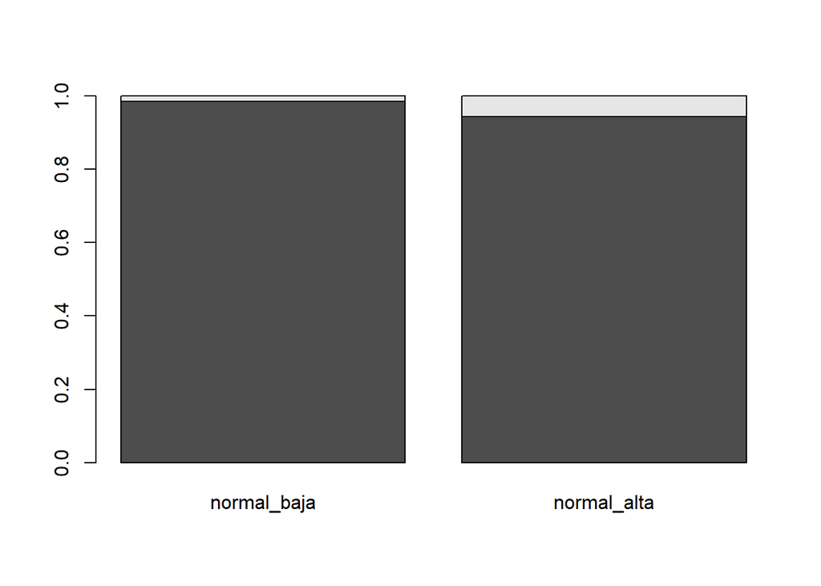

```r
barplot(tr_rel_col)
```

```r
chi.test.tr<-chisq.test(tr)
print(chi.test.tr)
```

```
##
##  Pearson's Chi-squared test with Yates' continuity correction
##
## data:  tr
## X-squared = 96.43, df = 1, p-value < 2.2e-16
```

Visualización y test Chi-cuadrado de Pearson de la relación icO3 - Vel_cat2:

```r
tv<-table(df_2b$icO3,df_2b$Vel_cat2)
tv
```

```
##
##     flojo moderado
##   0  5004     2234
##   1   125      101
```

```r
tv_rel<-prop.table(tv,1)
tv_rel
```

```
##
##         flojo  moderado
##   0 0.6913512 0.3086488
##   1 0.5530973 0.4469027
```

```r
tv_rel_col<-prop.table(tv,2)
tv_rel_col
```

```
##
##          flojo   moderado
##   0 0.97562878 0.95674518
##   1 0.02437122 0.04325482
```

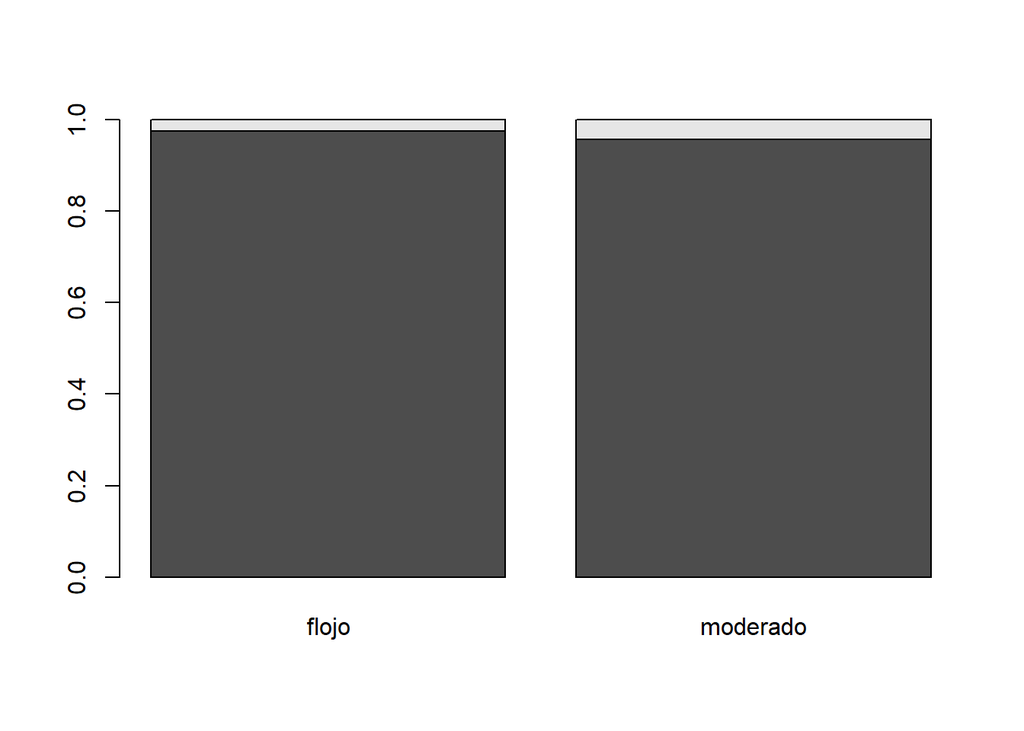

```r
barplot(tv_rel_col)
```

```r
chi.test.tv<-chisq.test(tv)
print(chi.test.tv)
```

```
##
##  Pearson's Chi-squared test with Yates' continuity correction
##
## data:  tv
## X-squared = 18.849, df = 1, p-value = 1.415e-05
```

Visualización y test Chi-cuadrado de Pearson de la relación icO3 - HR:

```r
th<-table(df_2b$icO3,df_2b$HR)
th
```

```
##
##       30   31   32   33   35   36   37   38   39   40   41   42   43   44   45
##   0    3    2    2    3    6    1    4    7    6    9    4    4    8    5   12
##   1    0    0    0    0    0    0    0    0    0    0    0    1    0    0    1
##
##       46   47   48   49   50   51   52   53   54   55   56   57   58   59   60
##   0    7   13   10   10   10   11   15   15   12   12   19   24   28   22   21
##   1    0    0    0    0    0    0    1    0    0    0    3    2    0    3    2
##
##       61   62   63   64   65   66   67   68   69   70   71   72   73   74   75
##   0   31   26   38   37   39   42   48   53   48   58   59   75   88   80   85
##   1    2    1    2    0    1    3    4    8    3    2    3    5    5    5    8
##
##       76   77   78   79   80   81   82   83   84   85   86   87   88   89   90
##   0   95   98  104  110  129  144  163  166  181  178  162  179  154  148  176
##   1    3    8    3    5    4    6    9    4    6    6    5   10   10    7   12
##
##       91   92   93   94   95   96   97   98   99  100
##   0  198  199  208  239  233  244  246  301  330 1741
##   1    7    6    6    9    7    5    4    4    8    7
```

```r
th_rel<-prop.table(th,1)
th_rel
```

```
##
##               30           31           32           33           35
##   0 0.0004144791 0.0002763194 0.0002763194 0.0004144791 0.0008289583
##   1 0.0000000000 0.0000000000 0.0000000000 0.0000000000 0.0000000000
##
##               36           37           38           39           40
##   0 0.0001381597 0.0005526389 0.0009671180 0.0008289583 0.0012434374
##   1 0.0000000000 0.0000000000 0.0000000000 0.0000000000 0.0000000000
##
##               41           42           43           44           45
##   0 0.0005526389 0.0005526389 0.0011052777 0.0006907986 0.0016579166
##   1 0.0000000000 0.0044247788 0.0000000000 0.0000000000 0.0044247788
##
##               46           47           48           49           50
##   0 0.0009671180 0.0017960763 0.0013815971 0.0013815971 0.0013815971
```

[output cut: 41 more lines]

```r
th_rel_col<-prop.table(th,2)
th_rel_col
```

```
##
##              30          31          32          33          35          36
##   0 1.000000000 1.000000000 1.000000000 1.000000000 1.000000000 1.000000000
##   1 0.000000000 0.000000000 0.000000000 0.000000000 0.000000000 0.000000000
##
##              37          38          39          40          41          42
##   0 1.000000000 1.000000000 1.000000000 1.000000000 1.000000000 0.800000000
##   1 0.000000000 0.000000000 0.000000000 0.000000000 0.000000000 0.200000000
##
##              43          44          45          46          47          48
##   0 1.000000000 1.000000000 0.923076923 1.000000000 1.000000000 1.000000000
##   1 0.000000000 0.000000000 0.076923077 0.000000000 0.000000000 0.000000000
##
##              49          50          51          52          53          54
##   0 1.000000000 1.000000000 1.000000000 0.937500000 1.000000000 1.000000000
```

[output cut: 33 more lines]

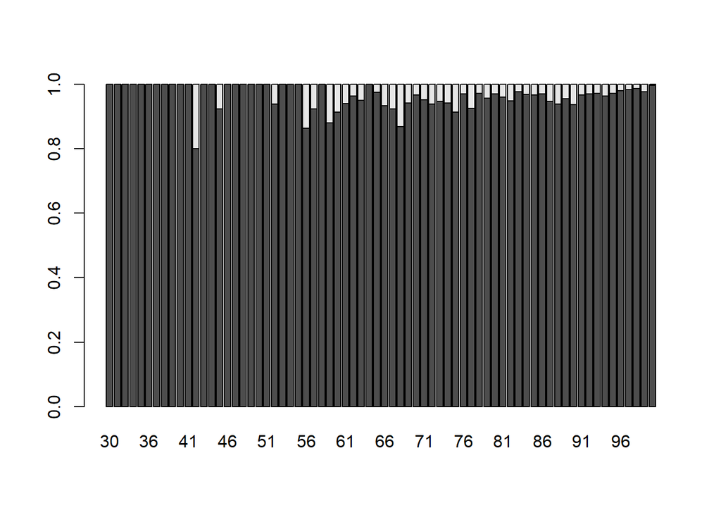

```r
barplot(th_rel_col)
```

```r
chi.test.th<-chisq.test(th)
print(chi.test.th)
```

```
##
##  Pearson's Chi-squared test
##
## data:  th
## X-squared = 157.16, df = 69, p-value = 7.909e-09
```

Como se puede ver en los test Chi-cuadrado de Pearson, el p_value es prácticamente 0 en los tres casos. Así que rechazamos la hipótesis nula de independencia de variables. Se acepta que existe una relación significativa entre icO3 y cada una de las otras tres variables.

- Cálculo de las OR (Odds-Ratio)

icO3 - RS_cat2:

```r
# Cáculo de las OR
tr_M<- addmargins(tr, FUN = list(Total = sum), quiet = TRUE)
tr_M
```

```
##
##         normal_baja normal_alta Total
##   0            4666        2572  7238
##   1              73         153   226
##   Total        4739        2725  7464
```

```r
p1_tr=((tr_M[2,2]/tr_M[3,2])/(1-(tr_M[2,2]/tr_M[3,2])))
p2_tr=((tr_M[2,1]/tr_M[3,1])/(1-(tr_M[2,1]/tr_M[3,1])))
OR_tr=p1_tr/p2_tr
OR_tr
```

```
## [1] 3.802265
```

OR de 3.802265, por lo que se interpreta que las odds de que el índice de calidad del aire basado en O3 sea bueno es 3.802265 veces mayor en valores de Radiación Solar normal_baja que para normal_alta.

icO3 - RS_Vel2:

```r
# Cáculo de las OR
tv_M<- addmargins(tv, FUN = list(Total = sum), quiet = TRUE)
tv_M
```

```
##
##         flojo moderado Total
##   0      5004     2234  7238
##   1       125      101   226
##   Total  5129     2335  7464
```

```r
p1_tv=((tv_M[2,2]/tv_M[3,2])/(1-(tv_M[2,2]/tv_M[3,2])))
p2_tv=((tv_M[2,1]/tv_M[3,1])/(1-(tv_M[2,1]/tv_M[3,1])))
OR_tv=p1_tv/p2_tv
OR_tv
```

```
## [1] 1.809862
```

OR de 1.809862, por lo que se interpreta que las odds de que el índice de calidad del aire basado en O3 sea bueno es 1.809862 veces mayor en valores de Velocidad del viento floja que para moderada.

icO3 - HR:

No se puede seguir el mismo procedimiento para calcular la OR que para las otras dos variables, ya que es una variable continua. Se debería construir un modelo de regresión logística.

## 2.2 Modelo de regresión logística

- Estimad el modelo de regresión logística tomando como variable dependiente icO3 y variable explicativa RS_cat2. Calculad la OR a partir de los resultados del modelo y su intervalo de confianza. ¿Se puede considerar que la radiación solar es un factor de riesgo?

```r
logit_model_1 <- glm(formula = icO3~RS_cat2, data=df_2b, family=binomial)
summary(logit_model_1)
```

```
##
## Call:
## glm(formula = icO3 ~ RS_cat2, family = binomial, data = df_2b)
##
## Deviance Residuals:
##     Min       1Q   Median       3Q      Max
## -0.3399  -0.3399  -0.1762  -0.1762   2.8890
##
## Coefficients:
##                    Estimate Std. Error z value Pr(>|z|)
## (Intercept)         -4.1576     0.1180 -35.248   <2e-16 ***
## RS_cat2normal_alta   1.3356     0.1444   9.252   <2e-16 ***
## ---
## Signif. codes:  0 '***' 0.001 '**' 0.01 '*' 0.05 '.' 0.1 ' ' 1
##
## (Dispersion parameter for binomial family taken to be 1)
##
##     Null deviance: 2025.9  on 7463  degrees of freedom
## Residual deviance: 1932.6  on 7462  degrees of freedom
## AIC: 1936.6
##
## Number of Fisher Scoring iterations: 7
```

```r
exp(cbind(coef(logit_model_1),confint(logit_model_1)))
```

```
##                                    2.5 %     97.5 %
## (Intercept)        0.01564509 0.01230476 0.01955106
## RS_cat2normal_alta 3.80226464 2.87682511 5.07056047
```

La radiación solar es un factor de riesgo ya que OR es mayor que 1, en concreto 3.80226464.

- Se crea un nuevo modelo con la misma variable dependiente y se añade al apartado a) la variable TMP. Interpretar si nos encontramos o no ante una posible variable de confusión.

```r
logit_model_2 <- glm(formula = icO3~RS_cat2+Tmp, data=df_2b, family=binomial)
summary(logit_model_2)
```

```
##
## Call:
## glm(formula = icO3 ~ RS_cat2 + Tmp, family = binomial, data = df_2b)
##
## Deviance Residuals:
##     Min       1Q   Median       3Q      Max
## -0.4597  -0.3087  -0.1943  -0.1633   3.1727
##
## Coefficients:
##                    Estimate Std. Error z value Pr(>|z|)
## (Intercept)        -5.12285    0.29484 -17.375  < 2e-16 ***
## RS_cat2normal_alta  1.11270    0.15522   7.169 7.57e-13 ***
## Tmp                 0.06878    0.01850   3.718 0.000201 ***
## ---
## Signif. codes:  0 '***' 0.001 '**' 0.01 '*' 0.05 '.' 0.1 ' ' 1
##
## (Dispersion parameter for binomial family taken to be 1)
##
##     Null deviance: 2025.9  on 7463  degrees of freedom
## Residual deviance: 1918.0  on 7461  degrees of freedom
## AIC: 1924
##
## Number of Fisher Scoring iterations: 7
```

```r
exp(coefficients(logit_model_2))
```

```
##        (Intercept) RS_cat2normal_alta                Tmp
##        0.005959011        3.042547893        1.071201516
```

El parámetro estimado de RS_cat no cambia mucho al introducir Tmp, en concreto pasa de 1.3356 a 1.11270 y, ademas, la proximidad de los valores entre la OR estimada de RS_cat2 con el primer modelo (3.80226464) y el modelo ajustado (3.042547893). Esto podría descartar que Tmp sea una variable de confusión.

- Se añade al modelo del apartado a) la variable HR. Estudiar la existencia o no de interacción entre las variables explicativas RS_cat2 y HR. Interpretar.

```r
logit_model_3=glm(formula=icO3~RS_cat2+HR+RS_cat2:HR, data=df_2b, family=binomial(link=logit))
summary(logit_model_3)
```

```
##
## Call:
## glm(formula = icO3 ~ RS_cat2 + HR + RS_cat2:HR, family = binomial(link = logit),
##     data = df_2b)
##
## Deviance Residuals:
##     Min       1Q   Median       3Q      Max
## -0.5603  -0.3351  -0.1760  -0.1376   3.0691
##
## Coefficients:
##                        Estimate Std. Error z value Pr(>|z|)
## (Intercept)           -0.195565   0.561377  -0.348    0.728
## RS_cat2normal_alta    -3.121116   0.787945  -3.961 7.46e-05 ***
## HR                    -0.045050   0.006621  -6.804 1.02e-11 ***
## RS_cat2normal_alta:HR  0.051090   0.009377   5.449 5.07e-08 ***
## ---
## Signif. codes:  0 '***' 0.001 '**' 0.01 '*' 0.05 '.' 0.1 ' ' 1
##
## (Dispersion parameter for binomial family taken to be 1)
##
##     Null deviance: 2025.9  on 7463  degrees of freedom
## Residual deviance: 1895.8  on 7460  degrees of freedom
## AIC: 1903.8
##
## Number of Fisher Scoring iterations: 7
```

Se observa que el estimador de interacción RS_cat2:HR es estadísticamente significativo.

- Se crea un nuevo modelo con las variables explicativas RS_cat2 y Dir_Aire. ¿Existe una mejora del modelo?

```r
logit_model_4=glm(formula=icO3~RS_cat2+Dir_Aire, data=df_2b, family=binomial)
summary(logit_model_4)
```

```
##
## Call:
## glm(formula = icO3 ~ RS_cat2 + Dir_Aire, family = binomial, data = df_2b)
##
## Deviance Residuals:
##     Min       1Q   Median       3Q      Max
## -0.4852  -0.2680  -0.1985  -0.1347   3.2440
##
## Coefficients:
##                      Estimate Std. Error z value Pr(>|z|)
## (Intercept)        -3.1101722  0.1646150 -18.894  < 2e-16 ***
## RS_cat2normal_alta  1.0360729  0.1488266   6.962 3.36e-12 ***
## Dir_Aire           -0.0060630  0.0007943  -7.633 2.29e-14 ***
## ---
## Signif. codes:  0 '***' 0.001 '**' 0.01 '*' 0.05 '.' 0.1 ' ' 1
##
## (Dispersion parameter for binomial family taken to be 1)
##
##     Null deviance: 2025.9  on 7463  degrees of freedom
## Residual deviance: 1865.6  on 7461  degrees of freedom
## AIC: 1871.6
##
## Number of Fisher Scoring iterations: 7
```

El indicador AIC= 1871.6 es menor que en los otros modelos, por lo que existe una mejora en el ajuste, aunque no muy grande.

## 2.3 Predicción

- Según el modelo del apartado d), calculad la probabilidad de que la concentración de O3 sea o no superior a 80, con unos valores de RS_cat2=“Normal_alta”y Dir_Aire=40:

```r
pred<-predict(logit_model_4, data.frame(RS_cat2="normal_alta",Dir_Aire=40),type = "response")
pred
```

```
##          1
## 0.08975586
```

El modelo del apartado d) nos predice una probabilidad del 9% de que la concentración de O3 sea superior a 80 o del 91% de que sea menor, con unos con unos valores de RS_cat2=“normal_alta”y Dir_Aire=40.

## 2.4 Bondad del ajuste

- Test de Hosman-Lemeshow para ver la bondad de ajuste, tomando el modelo del apartado d)

```r
hoslem.test(icO3, fitted(logit_model_4))
```

```
##
##  Hosmer and Lemeshow goodness of fit (GOF) test
##
## data:  icO3, fitted(logit_model_4)
## X-squared = 7464, df = 8, p-value < 2.2e-16
```

Observando el valor de p-value, rechazamos la hipótesis nula de que el modelo del apartado d) ajusta correctamente los datos.

## 2.5 Curva ROC

- Dibujar la curva ROC, y calcular el área debajo de la curva con el modelo del apartado d). Discutir el resultado.

```r
prob_low = predict(logit_model_4, df_2b, type="response")
r = roc(icO3,prob_low, data=df_2b)
```

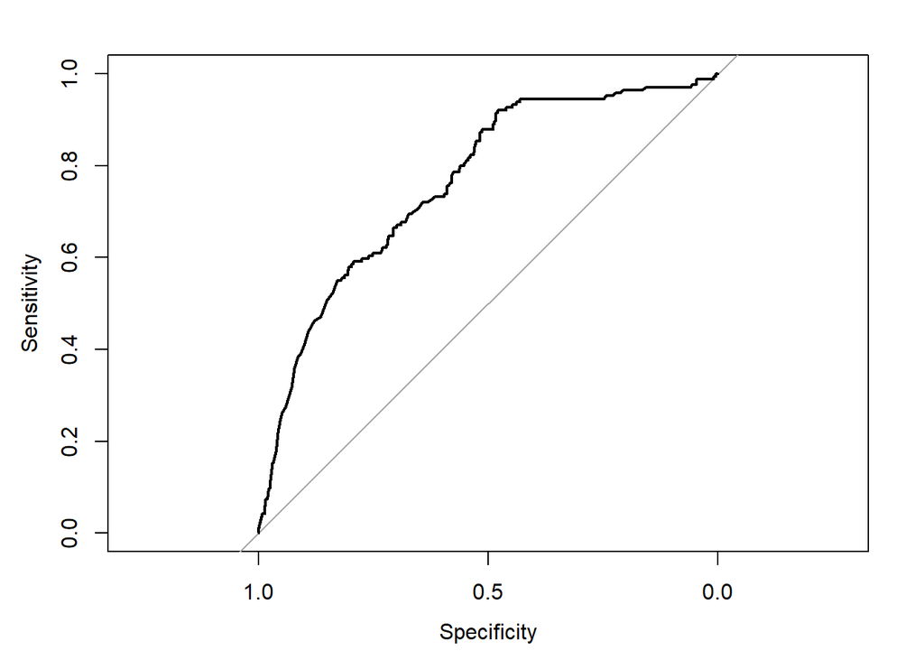

```r
plot(r)
```

```r
auc(r)
```

```
## Area under the curve: 0.7628
```

El área por debajo de esa curva toma el valor de 0.7628, por lo que el modelo discrimina de manera adecuada.

# 3 Conclusiones del análisis

En una segunda parte, se quiere estudiar la concentración de O3 del aire. Inicialmente se comprueba que, efectivamente, existe una relación significativa entre O3 y cada una de las siguientes variables: RS, velocidad del viento (Vel) y humedad relativa (HR). Tras esto se procede a trabajar el modelo, llegando a la conclusión de que el mejor ajuste se lleva a cabo empleando RS y Dir_Aire. Previamente se ha constatado que RS es un factor de riesgo y que existe interacción entre esta y HR, además, se ha descartado que Tmp sea una variable de confusión.

Con respecto a la bondad del ajuste, el test de Hosmer-Lemeshow descarta que el modelo ajuste correctamente los datos. Por otro lado, del estudio de la curva ROC, se puede deducir que el modelo del apartado d) discrimina de manera adecuada si la concentración de O3 es buena o mejorable.

# 4 Bibliografía

- Apuntes y recursos de la asignatura.